# Problem Set 2, due January 23th at 5:30 pm/January 24th 3:30pm

**Please Note:** This assignment will likely take you a *long* time, especially if you are new to Python. Start early!

## Introduction to the assignment

For this assignment, you will be using data from the [Progresa program](http://en.wikipedia.org/wiki/Oportunidades), a government social assistance program in Mexico. This program, as well as the details of its impact, are described in the paper "[School subsidies for the poor: evaluating the Mexican Progresa poverty program](http://www.sciencedirect.com/science/article/pii/S0304387803001858)", by Paul Shultz (available on Canvas). Please familiarize yourself with the PROGRESA program before beginning this problem set, so you have a rough sense of where the data come from and how they were generated. If you just proceed into the problem set without understanding Progresa or the data, it will be very difficult!

The goal of this problem set is to implement some of the basic econometric techniques that you are learning in class to measure the impact of Progresa on secondary school enrollment rates. The timeline of the program was:

- Baseline survey conducted in 1997
- Intervention begins in 1998, "Wave 1" of data collected in 1998
- "Wave 2 of data" collected in 1999
- Evaluation ends in 2000, at which point the control villages were treated.

When you are ready, download the progresa_sample.csv data from Canvas. The data are actual data collected to evaluate the impact of the Progresa program. In this file, each row corresponds to an observation taken for a given child for a given year. There are two years of data (1997 and 1998), and just under 40,000 children who are surveyed in each year. For each child-year observation, the following variables are collected:

| Variable name | Description |
| --- | --- |
| year | year in which data is collected |
| sex | male = 1 |
| indig | indigenous = 1 |
| dist_sec | nearest distance to a secondary school |
| sc | enrolled in school in year of survey |
| grc | grade enrolled |
| fam_n | family size |
| min_dist | min distance to an urban center |
| dist_cap | min distance to the capital |
| poor | poor = 1 |
| progresa | treatment =1 |
| hohedu | years of schooling of head of household |
| hohwag | monthly wages of head of household |
| welfare_index | welfare index used to classify poor |
| hohsex | gender of head of household (male=1) |
| hohage | age of head of household |
| age | years old |
| folnum | individual id |
| village | village id |
| sc97 | schooling in 1997 |

## Part 1: Descriptive analysis

### 1.1 Summary Statistics

Present summary statistics (mean and standard deviation) for all of the demographic variables in the dataset (i.e., everything except year, folnum, village). Present these in a single table alphabetized by variable name. Do NOT simply expect the grader to scroll through your output!

```python
import pandas as pd
import numpy as np
import matplotlib.pyplot as plt
from pylab import *
%matplotlib inline

progresa_df = pd.read_csv('progresa_sample.csv')

# Cleaning the data so it fits the description
progresa_df['poor'] = progresa_df['poor'].map({'pobre': 1, 'no pobre': 0})
progresa_df['progresa'] = progresa_df['progresa'].map({'basal' : 1, '0':0})

# Generating a Dataframe consisting the mean and standard deviation for each required variable.
# sorting the columns and storing them in a new dataframe
summary = progresa_df.reindex_axis(sorted(progresa_df.columns), axis=1)


# Method1: Inversing the Dataframe and then creating a new column.
summary = summary.transpose()
# Removing non-demographic columns
summary.drop(summary.index[[list(summary.index).index("year"), list(summary.index).index("folnum"), list(summary.index).index("village")]], inplace=True)

# Calculating Mena and Standar Deviation
summary['Mean'] = summary.mean(axis=1)
summary['Std'] = summary.std(axis=1)

# deleting multiple columns
summary.drop(summary.columns[:77250], inplace=True, axis=1)
summary
```

|  | Mean | Std |
| --- | --- | --- |
| age | 11.366460 | 3.167723 |
| dist_cap | 147.674452 | 76.062641 |
| dist_sec | 2.418910 | 2.234094 |
| fam_n | 7.215715 | 2.352885 |
| grc | 3.963537 | 2.499046 |
| grc97 | 3.705372 | 2.572371 |
| hohage | 44.436717 | 11.620296 |
| hohedu | 2.768104 | 2.656089 |
| hohsex | 0.925185 | 0.263093 |
| hohwag | 586.985312 | 788.128563 |
| indig | 0.298324 | 0.457522 |
| min_dist | 103.447520 | 42.089168 |
| poor | 0.846498 | 0.360470 |
| progresa | 0.615663 | 0.486438 |
| sc | 0.819818 | 0.384339 |
| sc97 | 0.813922 | 0.389169 |
| sex | 0.512211 | 0.499851 |
| welfare_index | 690.346564 | 139.490225 |

```python
len(progresa_df['village'].unique())
```

```
505
```

Initial observation from the Data: These columns are to be refactored to match the decribed values:

```
* 'poor' : pobre(spanish for poor) -> 1 and no pobre -> 0. This indicates whether the
* 'progresa' : basal -> 1 and 0 is as it is. This indicated whether the data is in treatement or control.
```

From here there are two way to proceed

```
* Take the transpose of the dataframe and calulate the mean of required columns.
* Slicing and storing the columns values as rows.
```

We have gone for the first method as it is memory conservative and the original Dataframe is unadulterated. Removing the non-demographic columns using their indices. Caluculating Mean and standard deviation as new columns and then removing the remaining 77250 data columns.

### 1.2 Differences at baseline?

Are the baseline (1997) demographic characteristics **for the poor** different in treatment and control villages? Hint: Use a T-Test to determine whether there is a statistically significant difference in the average values of each of the variables in the dataset. Focus only on the data from 1997 for individuals who are poor (i.e., poor=='pobre').

Present your results in a single table with the following columns and 14 (or so) rows:

| Variable name | Average value (Treatment villages) | Average value (Control villages) | Difference (Treat - Control) | p-value |
| --- | --- | --- | --- | --- |
| Male | ? | ? | ? | ? |

```python
from scipy import stats
from scipy.stats import t
```

```python
# Segregating into treatment and Control data
treatment_97 = pd.DataFrame(progresa_df[(progresa_df.year == 97) & (progresa_df.poor == 1) & (progresa_df.progresa == 1)])
control_97 = pd.DataFrame(progresa_df[(progresa_df.year == 97) & (progresa_df.poor == 1) & (progresa_df.progresa == 0)])

treatment_97.shape
```

```
(20222, 21)
```

```python
# Selecting rows where poor=1 and the year=97, and then grouping by 'progresa' column
ttest_df = progresa_df[(progresa_df.year == 97) & (progresa_df.poor == 1)].groupby('progresa').mean()
ttest_df.drop(ttest_df.columns[[0,9,16,17]], axis =1,inplace=True)

ttest_df = ttest_df.transpose()
# swapping columns to match the structure of the required table
ttest_df = ttest_df[[1,0]]

# Resetting Index
ttest_df.reset_index(level=0, inplace=True)
ttest_df.rename(columns={'index' : 'Variable name', 0: 'Average value (Control villages)', 1: 'Average value (Treatment villages)'}, inplace=True)

# This can be used to null the column name for a much cleaner output.
# ttest_df.columns.names = ['']

# List of all Variables
var_list = list(ttest_df['Variable name'])

# Calculating T test for the Treatment, Control
tt = list(stats.ttest_ind(treatment_97[var_list], control_97[var_list], nan_policy='omit'))

# Adding the remaining two columns.
ttest_df['Difference (Treat - Control)'] = tt[0]
ttest_df['p-value'] = tt[1]

# for a better look at the insignificant data with respect to the value of p
# ttest_df['p<0.05'] = ttest_df['p-value'] < 0.05

ttest_df
```

[output not shown]

Here we're applying a double sided t test, in an attempt to unearth any significant statistical diffrences between control and treatment groups.

Analysis:

**Aim:** To check for significant statistical differences between the baseline of both treatment and control groups before the treatment began.

**How were the groups selected:** *source* - Translated from Spanish. SEDESOL, Más Oportunidades para las Familias pobres - Primeros Avances, 393-394z

```
"The design of the impact evaluation of Progresa in communities and households is quasi-experimental...To undertake this component of the evaluation, a random sample of communities with 'high' or 'very high' degrees of marginalization were selected which would be incorporated into the program during Phase II (November 1997) and which would serve as the [treatment] communities...Another sample of communities with similar characteristics was randomly designated from those that could have been the object of later selection, and that could function as controls...the size of the sample was estimated starting from a universe of 4,546 localities to choose 330 base localities, and from a universe of 1,850 to choose 191 control localities, using a distribution proportional to the size of the locality."
```

From here we can observe that the treatment and control groups were randomly segregated.

**T Test:** The output of this test are the t-value and the p-value. *T value* can be labeled as a simple signal to noise ratio. When the t value is greater than the critical value of the data we then, reject the null hypothesis which deems no statistical difference between the two samples/vriables. Vice-versa when its less that the critical value.

**Conclusion:** the following variables have displayed statistically significant differences in average values at the baseline: *Sex* (gender), *dist_sec* (nearest distance to a secondary school), *min_dist* (min distance to an urban center), *dist_cap* (min distance to the capital), *hohedu* (years of schooling of head of household), *hohwag* (monthly wages of head of household), *welfare_index* (welfare index used to classify poor), *hohage* (age of head of household). As these have p values < 0.05.

### 1.3 Interpretation

- A: Are there statistically significant differences between treatment and control villages as baseline?
- B: Why does it matter if there are differences at baseline?
- C: What does this imply about how to measure the impact of the treatment?

**A: Are there statistically significant differences between treatment and control villages as baseline?** Observing the output of the T-Test the statistical dofferences are eveident between the two samples of treatment and control. Especially in the following variables.

```
- Sex, dsit_sec, min_dist, dist_cap, hohedu, hohwag, welfare_index, hohage
```

**B: Why does it matter if there are differences at baseline?** The differences in Baseline tell us that the samples, which were randomly picked and segregated between Treatment and Control were not perfectly random and were statistically different from each other. The basis of Treatment and control strategy is to observe the effect of a particular treatment on a group of indivisuals vs those which did not recieve the treatment. This requires us to start at an indistinguishable baseline in order to record accurate causal analysis and observe genuine patterns.

**C: What does this imply about how to measure the impact of the treatment?** From the above analysis we can observe that the two groups are statistically different even before the treatment commences. Therefore, we can assert that the segreagation performed randomly is flawed. Therefore we should come up with some other alternative which will help us segregate the population into two statistically indifferent groups. Therfore, instead of randomizing the segregation, we can use *Stratified Sampling*. This method can definitely help us achieve the required precision with the same sample size.

### 1.4 Graphical exploration, part 1

For each level of household head education, compute the average enrollment rate in 1997. Create a scatterplot that shows this relationship. What do you notice?

```
    hohedu        sc  count
0        0  0.776137   9957
1        1  0.768537   2549
2        2  0.794552   5617
3        3  0.802956   7374
4        4  0.842951   2738
5        5  0.849835   1212
6        6  0.878469   5225
7        7  0.889535    172
8        8  0.900000    290
9        9  0.925023   1067
10      10  0.865385     52
11      11  0.974359     39
12      12  0.982955    176
13      13  0.959459     74
14      14  0.880952     42
15      15  0.900000     30
16      16  0.941176     34
17      17  0.933333     15
18      18  1.000000     24
19      20  0.500000      2
```

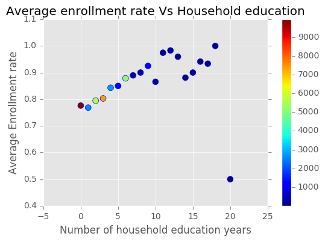

```python
# calculating the enrollment rate.
enrate = pd.DataFrame(progresa_df[(progresa_df.year == 97)].groupby('hohedu').mean()['sc'])

# calculating the frequency of observations for each level of household education.
countrate = pd.DataFrame(progresa_df[(progresa_df.year == 97)].groupby('hohedu').count()['sc'])
countrate.rename(columns={'sc':'count'}, inplace='True')
countrate.reset_index(level=0, inplace=True)
enrate.reset_index(level=0, inplace=True)

# merging the data frames
enrate = enrate.merge(countrate, on='hohedu')

print(enrate)

# plotting
matplotlib.style.use('ggplot')

plt.scatter(list(enrate['hohedu']), list(enrate['sc']), c=list(enrate['count']), s=50, edgecolor='blue')
plt.title('Average enrollment rate Vs Household education')
plt.xlabel('Number of household education years')
plt.colorbar()
plt.ylabel('Average Enrollment rate')
```

```python
progresa_df[(progresa_df.hohedu==20)].sc
```

```
45238    0.0
45239    NaN
45240    1.0
45241    NaN
Name: sc, dtype: float64
```

The plot obtained above alomst conforms to the general norm of an increasing relationship. I have also considered the frequency of the data as well and mapped the scatter density accordingly. Higher frequency, higher the density, and darker the color. This helps us to get a general sense of data and disregard outliers when making conlcusions. The increasing nature of the plot drops at points 10, 14 and then drastically at 20. Referring to the count curve we can see that the point 20 has only 2 data points in the average compared to 9000+ of 0 years. On further expounding on the data we found that we have 4 values corresponding to the 'hohedu' at 20. Out of which 2 are NaN and one is 0 and the other is 1. SO the data points are not sufficient enough to be considered. As the years increase we can also see the decrease in the number of values. Therfore, we can set up a threshold to be near the mode of the data, instead of the mean and disregard any count value less than this threshold. Doing this, we can conclude, mostly an increasing trend throughout, and strictly till the household education years equals 10. But the maximum value is obtained at 18 years

### 1.5 Graphical exploration, part 2

Create a histogram of village enrollment rates **among poor households in treated villages**, before and after treatment. Specifically, for each village, calculate the average rate of enrollment of poor households in treated villages in 1997, then compute the average rate of enrollment of poor households in treated villages in 1998. Create two separate histograms showing the distribution of these average enrollments rates, one histogram for 1997 and one histogram for 1998. On each histogram, draw a vertical line that intersects the x-axis at the average value (across all households).

- Does there appear to be a difference? Is this difference statistically significant?
- Which D estimator in Schultz (2004) does this approach correspond to?

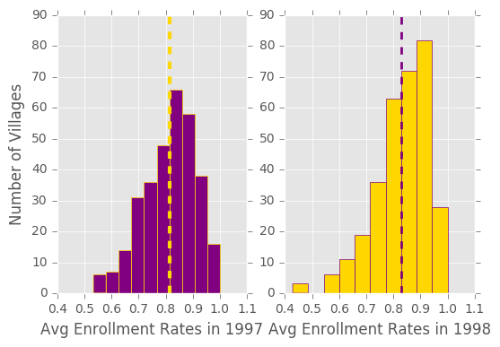

```
The mean enrollment BEFORE treatment is:  0.8138394110596501
The mean enrollment AFTER treatment is:  0.8295362042630732

The output of T test on the above values are:
 Ttest_indResult(statistic=-2.0157134865156379, pvalue=0.04424870036572115)
```

```python
# Preparing the Data for plot.
# Before treatment data
before_t = pd.DataFrame(progresa_df[(progresa_df.year == 97) & (progresa_df.progresa == 1) & (progresa_df.poor ==1)].groupby('village').mean()['sc'])
before_t.reset_index(level=0, inplace=True)
# After treatment data
after_t = pd.DataFrame(progresa_df[(progresa_df.year == 98) & (progresa_df.progresa == 1) & (progresa_df.poor ==1)].groupby('village').mean()['sc'])
after_t.reset_index(level=0, inplace=True)


fig = plt.figure()

# Histogram before the Treatment
ax1 = fig.add_subplot(121)
ax1.hist(before_t['sc'], color = "purple", edgecolor='gold')
xlabel("Avg Enrollment Rates in 1997")
ylabel("Number of Villages")
# setting the limits for axes, for better comparision
ax1.set_ylim([0,90])
ax1.set_xlim([0.4,1.1])
plt.axvline(before_t['sc'].mean(), color='gold', linestyle='dashed', linewidth=3)


# Histogram before the Treatment
ax2 = fig.add_subplot(122)
ax2.hist(after_t['sc'], color = 'gold', edgecolor='purple')
xlabel("Avg Enrollment Rates in 1998")
# setting the limits for axes, for better comparision
ax2.set_xlim([0.4,1.1])
plt.axvline(after_t['sc'].mean(), color='purple', linestyle='dashed', linewidth=2)
plt.show()

print()
print("The mean enrollment BEFORE treatment is: ", before_t['sc'].mean())
print("The mean enrollment AFTER treatment is: ", after_t['sc'].mean(), "\n")

# just like above we can see the differences in the data. using a T test.
print("The output of T test on the above values are:\n", stats.ttest_ind(before_t['sc'], after_t['sc'], nan_policy='omit'))
```

Here is the result, which will tell us what effect did the treatment have on the sample population. First set of observations include

```
- The noticable dip in number of villages with 'average enrollment rate' between 0.65 and 0.75.
- This is accompanies by an increase in villages with 0.4 'average enrollment rate' from 0 to 3.
- A noticable increase in #villages with 'avg enrol rate' > 0.75
```

Now, the *p-value* obtained from the t test is 0.04 < 0.05. This means that there is a statitical difference between them. But given that, difference is the measure of efectiveness of the treatment, we should be expecting a much better *p-value* which is farther from the 0.05 mark than the one obtained.

## Part 2: Measuring Impact

### 2.1 Simple differences: T-test

Start out by estimating the impact of Progresa using "simple differences." Restricting yourself to data from 1998 (after treatment).

- calculate the average enrollment rate among **poor** households in the Treatment villages and the average enrollment rate among **poor** households in the control villages.
- Which difference estimator in Schultz (2004) does this approach correspond to?
- Use a t-test to determine if this difference is statistically significant. What do you conclude?

```python
en_rate = pd.DataFrame(progresa_df[(progresa_df.poor==1) & (progresa_df.year==98)].groupby('progresa').mean()['sc'])
print('The average enrollement rate for poor households in the year 98 is as follows:')
print('Treatment villages: ', en_rate.sc[1])
print('Control villages: ', en_rate.sc[0])
en_rate.reset_index(level=0, inplace=True)

# Applying T-test to measure the statistical difference
treatment_98 = pd.DataFrame(progresa_df[(progresa_df.poor==1) & (progresa_df.progresa==1) & (progresa_df.year==98)])
control_98 = pd.DataFrame(progresa_df[(progresa_df.poor==1) & (progresa_df.progresa==0)& (progresa_df.year==98)])

tt2 = stats.ttest_ind(treatment_98['sc'], control_98['sc'], nan_policy='omit')
print('\nThe output of T test is as follows:\n', tt2)
```

```
The average enrollement rate for poor households in the year 98 is as follows:
Treatment villages:  0.846479121395
Control villages:  0.80763695673

The output of T test is as follows:
 Ttest_indResult(statistic=8.3587205674183735, pvalue=6.6363444473781018e-17)
```

### 2.2 Simple differences: Regression

Estimate the effects of Progresa on enrollment using a regression model, by regressing the 1998 enrollment rates **of the poor** on treatment assignment. Discuss the following:

- Based on this model, how much did Progresa increase the likelihood of a child enrolling?
- How does your regression estimate compare to your t-test estimate from part 2.1?
- Based on this regression model, can we reject the null hypothesis that the treatment effects are zero?
- What is the counterfactual assumption underlying this regression?

```python
import statsmodels.formula.api as smf
en_regr = progresa_df[(progresa_df.year==98) & (progresa_df.poor ==1)]

regr = smf.ols('sc ~ progresa', data= en_regr).fit()
regr.summary()
```

OLS Regression Results

| Dep. Variable: | sc | R-squared: | 0.003 |
| --- | --- | --- | --- |
| Model: | OLS | Adj. R-squared: | 0.003 |
| Method: | Least Squares | F-statistic: | 69.87 |
| Date: | Thu, 26 Jan 2017 | Prob (F-statistic): | 6.64e-17 |
| Time: | 16:14:23 | Log-Likelihood: | -11926. |
| No. Observations: | 27450 | AIC: | 2.386e+04 |
| Df Residuals: | 27448 | BIC: | 2.387e+04 |
| Df Model: | 1 |  |  |
| Covariance Type: | nonrobust |  |  |

|  | coef | std err | t | P>\|t\| | [95.0% Conf. Int.] |
| --- | --- | --- | --- | --- | --- |
| Intercept | 0.8076 | 0.004 | 220.676 | 0.000 | 0.800 0.815 |
| progresa | 0.0388 | 0.005 | 8.359 | 0.000 | 0.030 0.048 |

| Omnibus: | 7638.939 | Durbin-Watson: | 1.734 |
| --- | --- | --- | --- |
| Prob(Omnibus): | 0.000 | Jarque-Bera (JB): | 15767.534 |
| Skew: | -1.767 | Prob(JB): | 0.00 |
| Kurtosis: | 4.140 | Cond. No. | 3.01 |

**Based on this model, how much did Progresa increase the likelihood of a child enrolling?** We can observe that the parameter associated with progresa is positive, hence an increasing relationship. The magnitude of this parameter found is 0.0388, the magnitude of the intercept is found to be 0.8076. Therefore Progresa increases the likelihood of enrollment by 0.0388 i.e. likelihood of enrollment without progresa is 0.8076 and with progresa is 0.8464

**How does your regression estimate compare to your t-test estimate from part 2.1?** The regression model here validates the values obtained in 2.1. Avg. enrolleent rate of control villages(0.80) is the same while the avg. enrollment rae of treatment, according to the model is given as 0.80 + 0.0388 = 0.84, which is same as well.

**What is the counterfactual assumption underlying this regression?** The counter factual assumption underlying this regression is that the avg. enrollement rate of the treatment villages would be same as that in the control villages.

```python
## LINEAR REGRESSION IN DEPTH.!!!
# a small test to see the imapct of a completrly opposite variable on the values of 'sc'
test_df = progresa_df.copy()
test_df['v1'] = test_df.sc == 0
test_df['v3'] = test_df.sc == 1

# v1 has the opposite value of sc.
test_df['v1'] = test_df['v1'].map({True : 1, False:0})
# v3 has the same value of sc.
test_df['v3'] = test_df['v3'].map({True : 1, False:0})

# Regression test
test_regr = smf.ols(formula='sc ~ v1 + v3', data=test_df).fit()
test_regr.summary()
```

OLS Regression Results

| Dep. Variable: | sc | R-squared: | 1.000 |
| --- | --- | --- | --- |
| Model: | OLS | Adj. R-squared: | 1.000 |
| Method: | Least Squares | F-statistic: | 3.253e+30 |
| Date: | Thu, 26 Jan 2017 | Prob (F-statistic): | 0.00 |
| Time: | 16:14:23 | Log-Likelihood: | 2.0017e+06 |
| No. Observations: | 68797 | AIC: | -4.003e+06 |
| Df Residuals: | 68795 | BIC: | -4.003e+06 |
| Df Model: | 1 |  |  |
| Covariance Type: | nonrobust |  |  |

|  | coef | std err | t | P>\|t\| | [95.0% Conf. Int.] |
| --- | --- | --- | --- | --- | --- |
| Intercept | 0.3333 | 1.85e-16 | 1.8e+15 | 0.000 | 0.333 0.333 |
| v1 | -0.3333 | 3.44e-16 | -9.7e+14 | 0.000 | -0.333 -0.333 |
| v3 | 0.6667 | 2.29e-16 | 2.91e+15 | 0.000 | 0.667 0.667 |

| Omnibus: | 17225.930 | Durbin-Watson: | 1.021 |
| --- | --- | --- | --- |
| Prob(Omnibus): | 0.000 | Jarque-Bera (JB): | 33456.389 |
| Skew: | 1.664 | Prob(JB): | 0.00 |
| Kurtosis: | 3.770 | Cond. No. | 1.92e+16 |

### For personal understanding only.

We see here that the coefficient of v1 is -0.3333 and v3 is 0.6667 and the intercept is 0.3333. confirming that negative relation actually means an opposite nature.!

### 2.3 Multiple Regression

Re-run the above regression estimated but this time include a set of control variables. Include, for instance, age, distance to a secondary school, gender, education of household head, indigenous, etc.

- How do the controls affect the point estimate of treatment effect?
- How do the controls affect the standard error on the treatment effect?
- How do you interpret the differences (or similarities) between your estimates of 2.2 and 2.3?

```python
multi_regr = smf.ols('sc ~ progresa + age + dist_sec + sex + hohedu + indig', data=en_regr).fit()
multi_regr.summary()
```

OLS Regression Results

| Dep. Variable: | sc | R-squared: | 0.268 |
| --- | --- | --- | --- |
| Model: | OLS | Adj. R-squared: | 0.268 |
| Method: | Least Squares | F-statistic: | 1666. |
| Date: | Thu, 26 Jan 2017 | Prob (F-statistic): | 0.00 |
| Time: | 16:14:23 | Log-Likelihood: | -7671.8 |
| No. Observations: | 27340 | AIC: | 1.536e+04 |
| Df Residuals: | 27333 | BIC: | 1.542e+04 |
| Df Model: | 6 |  |  |
| Covariance Type: | nonrobust |  |  |

|  | coef | std err | t | P>\|t\| | [95.0% Conf. Int.] |
| --- | --- | --- | --- | --- | --- |
| Intercept | 1.5235 | 0.009 | 161.784 | 0.000 | 1.505 1.542 |
| progresa | 0.0356 | 0.004 | 8.920 | 0.000 | 0.028 0.043 |
| age | -0.0655 | 0.001 | -95.686 | 0.000 | -0.067 -0.064 |
| dist_sec | -0.0119 | 0.001 | -13.642 | 0.000 | -0.014 -0.010 |
| sex | 0.0310 | 0.004 | 7.995 | 0.000 | 0.023 0.039 |
| hohedu | 0.0087 | 0.001 | 11.147 | 0.000 | 0.007 0.010 |
| indig | 0.0468 | 0.004 | 11.306 | 0.000 | 0.039 0.055 |

| Omnibus: | 2974.429 | Durbin-Watson: | 1.717 |
| --- | --- | --- | --- |
| Prob(Omnibus): | 0.000 | Jarque-Bera (JB): | 4048.759 |
| Skew: | -0.935 | Prob(JB): | 0.00 |
| Kurtosis: | 3.239 | Cond. No. | 60.4 |

### 2.4 Difference-in-Difference, version 1 (tabular)

Thus far, we have computed the effects of Progresa by estimating the difference in 1998 enrollment rates across villages. An alternative approach would be to compute the treatment effect using a difference-in-differences framework.

Begin by estimating the average treatment effects of the program for poor households using data from 1997 and 1998. Specifically, calculate the difference (between 1997 and 1998) in enrollment rates among poor households in treated villages; then compute the difference (between 1997 and 1998) in enrollment rates among poor households in treated villages. The difference between these two differences is your estimate.

- What is your estimate of the impact, and how does it compare to your earlier (simple difference) results?
- What is the counterfactual assumption underlying this estimate?

```python
# Splitting the control group.
en_control_97 = progresa_df[(progresa_df.poor==1) & (progresa_df.progresa==0) & (progresa_df.year==97)]
en_control_98 = progresa_df[(progresa_df.poor==1) & (progresa_df.progresa==0) & (progresa_df.year==98)]

# SPlitting the treatment group.
en_treat_97 = progresa_df[(progresa_df.poor==1) & (progresa_df.progresa==1) & (progresa_df.year==97)]
en_treat_98 = progresa_df[(progresa_df.poor==1) & (progresa_df.progresa==1) & (progresa_df.year==98)]

# Creating a new Dataframe
index = ['Control sample', 'Treatment sample']
cols = ['Avg. Enrollment rate in 97', 'Avg. Enrollment rate in 98']
new_diff = pd.DataFrame(index = index, columns = cols)

# filling in the values
new_diff.loc['Control sample', 'Avg. Enrollment rate in 97'] = en_control_97['sc'].mean()
new_diff.loc['Control sample', 'Avg. Enrollment rate in 98'] = en_control_98['sc'].mean()
new_diff.loc['Treatment sample', 'Avg. Enrollment rate in 97'] = en_treat_97['sc'].mean()
new_diff.loc['Treatment sample', 'Avg. Enrollment rate in 98'] = en_treat_98['sc'].mean()

new_diff['Difference'] = new_diff['Avg. Enrollment rate in 98'] - new_diff['Avg. Enrollment rate in 97']

print("The Diff-in-Diff estimate is: ", new_diff.Difference[1] - new_diff.Difference[0])

print("\nThe Tabular representation of the Differences:")
new_diff
```

```
The Diff-in-Diff estimate is:  0.031331280319323085

The Tabular representation of the Differences:
```

|  | Avg. Enrollment rate in 97 | Avg. Enrollment rate in 98 | Difference |
| --- | --- | --- | --- |
| Control sample | 0.815186 | 0.807637 | -0.00754905 |
| Treatment sample | 0.822697 | 0.846479 | 0.0237822 |

**What is your estimate of the impact, and how does it compare to your earlier (simple difference) results?** The estimate of the impact is 0.0313. This indicates that the increase in the enrollment rate can be credited to the progresa treatment. The diff-in-diff estimate is lower than the earlier observed point estimate of 0.0388(univariate) and 0.0356(multivariate). Since, the lower multivariate estimate had a better std. error, we could say that the diff-in-diff estimate is more accurate

**What is the counterfactual assumption underlying this estimate?** The counterfactual assumption would be that the avg. enrollment change in the treatment group and control group would be same irrespective of the treatment.

### 2.5 Difference-in-Difference, version 1 (regression)

Now use a regression specification to estimate the average treatment effect of the program (on the poor) in a difference-in-differences framework. Include at least 5 control variables.

- What is your estimate of the impact of Progresa? Be very specific in interpreting your coefficients and standard errors, and make sure to specify exactly what units you are measuring and estimating.
- How do these estimates of the treatment effect compare to the estimates based on the simple difference?
- How do these estimates compare to the difference-in-difference estimates from 2.4 above? What accounts for these differences?
- What is the counterfactual assumption underlying this regression?

```python
# TO get a separate statistic with respect to the year we create a dependent/correlated variable: afterT (1= after treatment).
lm_diff = progresa_df[(progresa_df.poor==1)]
lm_diff.loc[lm_diff.year==97, 'afterT'] = 0
lm_diff.loc[lm_diff.year==98, 'afterT'] = 1

# running a regression model, we'll chose the previously chosen control variables to make the intercept comparable
ddregr = smf.ols(formula='sc ~ progresa + afterT + progresa:afterT + age + dist_sec + sex + hohedu + indig', data =lm_diff).fit()
ddregr.summary()
```

OLS Regression Results

| Dep. Variable: | sc | R-squared: | 0.279 |
| --- | --- | --- | --- |
| Model: | OLS | Adj. R-squared: | 0.279 |
| Method: | Least Squares | F-statistic: | 2810. |
| Date: | Thu, 26 Jan 2017 | Prob (F-statistic): | 0.00 |
| Time: | 16:14:23 | Log-Likelihood: | -16717. |
| No. Observations: | 58165 | AIC: | 3.345e+04 |
| Df Residuals: | 58156 | BIC: | 3.353e+04 |
| Df Model: | 8 |  |  |
| Covariance Type: | nonrobust |  |  |

|  | coef | std err | t | P>\|t\| | [95.0% Conf. Int.] |
| --- | --- | --- | --- | --- | --- |
| Intercept | 1.4940 | 0.006 | 231.606 | 0.000 | 1.481 1.507 |
| progresa | 0.0043 | 0.004 | 1.137 | 0.256 | -0.003 0.012 |
| afterT | 0.0270 | 0.004 | 6.204 | 0.000 | 0.018 0.036 |
| progresa:afterT | 0.0314 | 0.006 | 5.685 | 0.000 | 0.021 0.042 |
| age | -0.0655 | 0.000 | -144.433 | 0.000 | -0.066 -0.065 |
| dist_sec | -0.0110 | 0.001 | -17.788 | 0.000 | -0.012 -0.010 |
| sex | 0.0339 | 0.003 | 12.672 | 0.000 | 0.029 0.039 |
| hohedu | 0.0076 | 0.001 | 14.110 | 0.000 | 0.007 0.009 |
| indig | 0.0496 | 0.003 | 17.304 | 0.000 | 0.044 0.055 |

| Omnibus: | 5523.777 | Durbin-Watson: | 1.484 |
| --- | --- | --- | --- |
| Prob(Omnibus): | 0.000 | Jarque-Bera (JB): | 7269.312 |
| Skew: | -0.864 | Prob(JB): | 0.00 |
| Kurtosis: | 3.113 | Cond. No. | 70.8 |

In order to run the regression test in the diff-in-diff framework we have to consider values of the feature 'year' interactively with the feature 'progresa' i.e in year=97 vs year=98. We can simply assign 1 and 0 for the year 98 and 97 respectively. This would give us the before and after period. Earlier we considered only the data in the year 1998 which is post treatment.

**How do these estimates compare to the difference-in-difference estimates from 2.4 above? What accounts for these differences?** The estimate of the the effect of progresa on the population, by the regression model, is given by the sum of all the values of the coefficient influencing the contol variable 'progresa'. In the previous model we calculated the differences in the both treatment and control group before and after the treatment commenced. The differences in the values isn't significant but in the current method we've considered other control vairables as well as an interation variable of 'progresa' and 'year', which puts us in a more accurate and inclusive estimate.

**What is the counterfactual assumption underlying this regression?** The counter factual assumption would be that, The trends of avg enrollment rate on both the groups will be the same even without the treatment.

### 2.6 Difference-in-Difference, version 2

In the previous problem, you estimated a difference-in-differences model that compared changes in enrollment rates over time across treatment and control villages. An alternative approach would be to compare enrollment rates in 1998 between poor and non-poor across treatment and control villages.

- How would we estimate this version of the treatment effects in a regression model?
- What is the counterfactual assumption underlying this regression?
- How do these treatment effects compare to the estimates above?
- Discuss some possible explanations for differences or similarities

```python
# Including the interation variable between the poor and progresa as well.
dd_lm2 = smf.ols(formula='sc ~ progresa + poor + progresa:poor + age + dist_sec + sex + hohedu + indig', data = progresa_df).fit()
dd_lm2.summary()
```

OLS Regression Results

| Dep. Variable: | sc | R-squared: | 0.276 |
| --- | --- | --- | --- |
| Model: | OLS | Adj. R-squared: | 0.276 |
| Method: | Least Squares | F-statistic: | 3273. |
| Date: | Thu, 26 Jan 2017 | Prob (F-statistic): | 0.00 |
| Time: | 16:14:23 | Log-Likelihood: | -20651. |
| No. Observations: | 68543 | AIC: | 4.132e+04 |
| Df Residuals: | 68534 | BIC: | 4.140e+04 |
| Df Model: | 8 |  |  |
| Covariance Type: | nonrobust |  |  |

|  | coef | std err | t | P>\|t\| | [95.0% Conf. Int.] |
| --- | --- | --- | --- | --- | --- |
| Intercept | 1.5147 | 0.008 | 197.335 | 0.000 | 1.500 1.530 |
| progresa | 0.0270 | 0.007 | 4.124 | 0.000 | 0.014 0.040 |
| poor | -0.0103 | 0.006 | -1.841 | 0.066 | -0.021 0.001 |
| progresa:poor | -0.0080 | 0.007 | -1.120 | 0.263 | -0.022 0.006 |
| age | -0.0653 | 0.000 | -155.008 | 0.000 | -0.066 -0.064 |
| dist_sec | -0.0115 | 0.001 | -19.644 | 0.000 | -0.013 -0.010 |
| sex | 0.0333 | 0.003 | 13.333 | 0.000 | 0.028 0.038 |
| hohedu | 0.0082 | 0.000 | 17.161 | 0.000 | 0.007 0.009 |
| indig | 0.0495 | 0.003 | 17.788 | 0.000 | 0.044 0.055 |

| Omnibus: | 6126.484 | Durbin-Watson: | 1.493 |
| --- | --- | --- | --- |
| Prob(Omnibus): | 0.000 | Jarque-Bera (JB): | 7952.798 |
| Skew: | -0.834 | Prob(JB): | 0.00 |
| Kurtosis: | 2.986 | Cond. No. | 114. |

**How would we estimate this version of the treatment effects in a regression model?** The effect of treatment, in this model, is given by the sum of coefficients influencing the 'profresa' variable. Here it is **0.027 - 0.008 x poor**, where poor is the value indicating whether the subject is labeed as poor or not.

**What is the counterfactual assumption underlying this regression?** The counterfactual assumption underlying the regression is that, the changes in avg. enrollment rate is same for 'pobre'(poor) and 'no pobre'(not poor) households even in the absence of treatment.

**How do these treatment effects compare to the estimates above?** The treatment effects of this estimate is much lower than the one in **2.5**. The combined estimate of the progresa on the avg. enrollment rate here is given by: **0.027 - 0.0080 x poor**. The coefficient of the interation variable of the treatment and the status of the households is negative and almost zero that woudl indicate almost an opposite impact of the variables on the avg. enrollment rate (Tested in the cell before 2.3). Whereas, in the previous estimate of **2.5** we have a much more realistic and accurate measure of the estiamte.

**Discuss some possible explanations for differences or similarities** This could be because there is no expected effect of the interation of these two variables. This conforms to the progresa model where only the poor households are recipient of the treatment. One other uncanny observation is the negative coefficent of 'poor' because, the household recieves the progresa treatment only when the poor value is 1. There is every reason for this coefficient to be positive, as we would expect that the increase in enrollment rate would be more in poor households.

### 2.7 Spillover effects (extra credit)

Thus far, we have focused on the impact of PROGRESA on poor households. Repeat your analysis in 2.5, using a double-difference regression to estimate the impact of PROGRESA on non-poor households. In other words, compare the difference in enrollments between 1997 and 1998 for non-poor households in treatment villages with the difference in enrollments between 1997 and 1998 for non-poor households in control villages.

- A: Describe one or two reasons why PROGRESA might have impacted non-poor households.
- B: Do you observe any impacts of PROGRESA on the non-poor?
- C: What is the identifying assumption that you are using to estimate the impact of PROGRESA on non-poor households.

```python
# TO get a separate statistic with respect to the year we create a dependent/correlated variable: afterT (1= after treatment).
lm_diff2 = progresa_df[(progresa_df.poor==0)]
lm_diff2.loc[lm_diff2.year==97, 'afterT'] = 0
lm_diff2.loc[lm_diff2.year==98, 'afterT'] = 1

print("Total number of instances where non-poor subjects were also handed the treatment are: ", len(progresa_df[(progresa_df.poor==0) & (progresa_df.progresa==1)]))

# running a regression model, we'll chose the previously chosen control variables to make the intercept comparable
ddregr2 = smf.ols(formula='sc ~ progresa + afterT + progresa:afterT + age + dist_sec + sex + hohedu + indig', data =lm_diff).fit()
ddregr2.summary()
```

```
Total number of instances where non-poor subjects were also handed the treatment are:  7116
```

OLS Regression Results

| Dep. Variable: | sc | R-squared: | 0.279 |
| --- | --- | --- | --- |
| Model: | OLS | Adj. R-squared: | 0.279 |
| Method: | Least Squares | F-statistic: | 2810. |
| Date: | Thu, 26 Jan 2017 | Prob (F-statistic): | 0.00 |
| Time: | 16:14:23 | Log-Likelihood: | -16717. |
| No. Observations: | 58165 | AIC: | 3.345e+04 |
| Df Residuals: | 58156 | BIC: | 3.353e+04 |
| Df Model: | 8 |  |  |
| Covariance Type: | nonrobust |  |  |

|  | coef | std err | t | P>\|t\| | [95.0% Conf. Int.] |
| --- | --- | --- | --- | --- | --- |
| Intercept | 1.4940 | 0.006 | 231.606 | 0.000 | 1.481 1.507 |
| progresa | 0.0043 | 0.004 | 1.137 | 0.256 | -0.003 0.012 |
| afterT | 0.0270 | 0.004 | 6.204 | 0.000 | 0.018 0.036 |
| progresa:afterT | 0.0314 | 0.006 | 5.685 | 0.000 | 0.021 0.042 |
| age | -0.0655 | 0.000 | -144.433 | 0.000 | -0.066 -0.065 |
| dist_sec | -0.0110 | 0.001 | -17.788 | 0.000 | -0.012 -0.010 |
| sex | 0.0339 | 0.003 | 12.672 | 0.000 | 0.029 0.039 |
| hohedu | 0.0076 | 0.001 | 14.110 | 0.000 | 0.007 0.009 |
| indig | 0.0496 | 0.003 | 17.304 | 0.000 | 0.044 0.055 |

| Omnibus: | 5523.777 | Durbin-Watson: | 1.484 |
| --- | --- | --- | --- |
| Prob(Omnibus): | 0.000 | Jarque-Bera (JB): | 7269.312 |
| Skew: | -0.864 | Prob(JB): | 0.00 |
| Kurtosis: | 3.113 | Cond. No. | 70.8 |

**A: Describe one or two reasons why PROGRESA might have impacted non-poor households.** Firstly, one of the possibility can be the contamination of data i.e. the possibility of families migrating from the control locality to the treatment locality. This could increase their enrollment rate similar to that of treatment but the resulting data would show up on the control side. Second reason could be that the non-poor households could have been sending their childeren to school on noticing it's importance from the perspective of progresa program or could also be a socical competition. This could account towards the increase in the enrollment rate of non poor households.

**C: What is the identifying assumption that you are using to estimate the impact of PROGRESA on non-poor households.** The assumption here, that helps in identifying the estimate of impact of progresa on avg. enrollment rate is, that thfe progresa program could've in some way effected those household which were non-poor or, assuming that the effect, of progresa, would've anyways happened even without the treatment actually existing.

### 2.8 Summary

Based on all the analysis you have undertaken to date, do you thik that Progresa had a causal impact on the enrollment rates of poor households in Mexico?

Given these above tests whcih were primal of all conducted, The increase in enrollment exists but, in order to assert fair judgement on the Progresa plan we would need some economic details which would give us insight into the profit and loss data. Considering the monetary aspect of any program is paramount, althogh in social terms it can be compared to the amount of effort put into the program and the social benefits recieved from it. This being said, from the analysis it appears that the turnaround of the enrollment rate doesn't do justice to all the amount of subsidy provided to each family. There could be some families that recieved the subsidy but did not enroll their kids into the schools. There's another possibility that the amount of subsidy wasn't enough in terms of quantity because, looking at the data, some of the companies were earning really low and the subsidy would've just helped them making ends meet this could've compelled their childeren to avoid school in order to reduce financial stress.